# Final Project: Boston Housing

Canali, Ippolito, Olivo, Vizzo

2023-01-18

# Description of the project’s aim

The `Boston` dataset of the `MASS` package pertains to housing values in the suburbs of Boston. The data frame consists of 506 rows and 14 columns. The project aim is to fit a model which describes at best the domestic property median value (medv) in the examined area. We considered several factors in order to determine the most influential ones.

First, we divided the dataset in training and test set and, eventually, we used the training set to fit different models. We looked for the best approach among linear models, generalized linear models and generalized additive models. For every category, we compared nested models using the analysis of variance (anova) to determine the one which worked better with respect to the data. Then, we compared the best model of each type using the Akaike information criteria. At last, we measured the performance of the selected models on the test set using the root mean squared error (RMSE), the mean absolute error (MAE), and the mean absolute percentage error (MAPE).

Reported below a brief description of the considered variables:

| Variable’s name | Brief Description |
| --- | --- |
| crim | Per capita crime rate by town |
| zn | Proportion of residential land zoned for lots over 25,000 sq.ft |
| indus | Proportion of non-retail business acres per town |
| chas | Charles River dummy variable (= 1 if tract bounds river; 0 otherwise) |
| nox | Nitrogen oxides concentration (parts per 10 million) |
| rm | Average number of rooms per dwelling |
| age | Proportion of owner-occupied units built prior to 1940 |
| dis | Weighted mean of distances to five Boston employment centres |
| rad | Index of accessibility to radial highways |
| tax | Full-value property-tax rate per $10,000 |
| ptratio | Pupil-teacher ratio by town |
| black | $1000(Bk - 0.63)^2$ where Bk is the proportion of blacks by town |
| lstat | Lower status of the population (percent) |
| medv | Median value of owner-occupied homes in $1000s |

# Exploratory data analysis

First, we load the `Boston` dataset, we divide it in training and test set, and we check whether it contains any null values. Also, we transform categorical variables into factors.

```r
library(MASS)
library(rsample)

#Dataset division

set.seed(40)

Boston_split <- initial_split(Boston,prop = 0.8)
data <- training(Boston_split)
test <- testing(Boston_split)

#Check for any missing values

print(any(is.na(Boston)))
```

```
## [1] FALSE
```

```r
#Make categorical variables as factors

data$chas = as.factor(data$chas)
data$rad = as.factor(data$rad)
test$chas = as.factor(test$chas)
test$rad = as.factor(test$rad)
```

Then, we analyze the correlation between the target variable and the predictors, and the correlation among predictors themselves. This is done to determine the extent of linear independence of the columns of the matrix $X$. Note that we select only the numerical variables for correlation.

```r
#Correlation between x and y

x = data[,-c(4,9,14)]
y = data[,14]

cor(x,y)
```

```
##               [,1]
## crim    -0.4081755
## zn       0.3980011
## indus   -0.5173718
## nox     -0.4436335
## rm       0.6977049
## age     -0.3966670
## dis      0.2687039
## tax     -0.4900792
## ptratio -0.5445338
## black    0.3326002
## lstat   -0.7472417
```

We first notice that the variables zn, rm, dis and black are positively correlated with the target variable medv, while the other variables display a negative correlation. Also, the high absolute value of the correlation between medv and the predictors rm and lstat suggests that rm and lstat may be strong linear predictors.

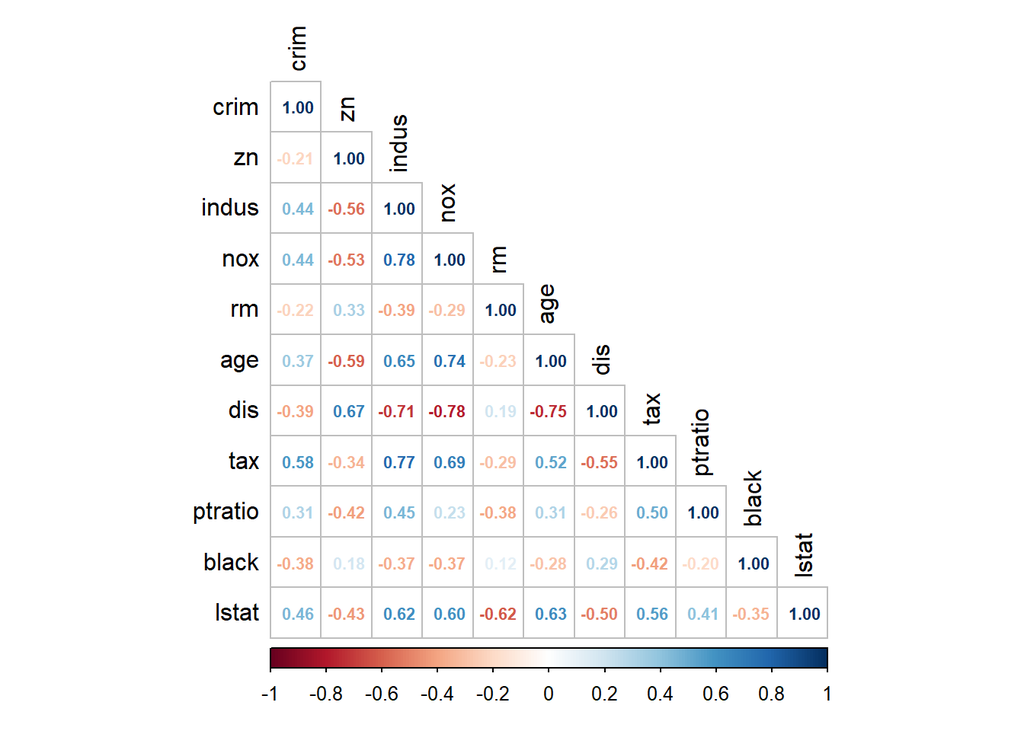

```r
#Correlation between x and x

library(corrplot)
M = data[,-c(4,9,14)]
corrplot(cor(M), method = "number", type = "lower",number.cex = 0.7, tl.col = "black")
```

By plotting the pairwise correlations between each of the variables, it is possible to see that some predictors display high correlation with the others. Among these, we highlight indus, age and nox. Further analysis may lead to the exclusion of some of them from the models.

Now, we display the scatter plots of medv against every $x$ variable, and the boxplots of the two categorical variables:

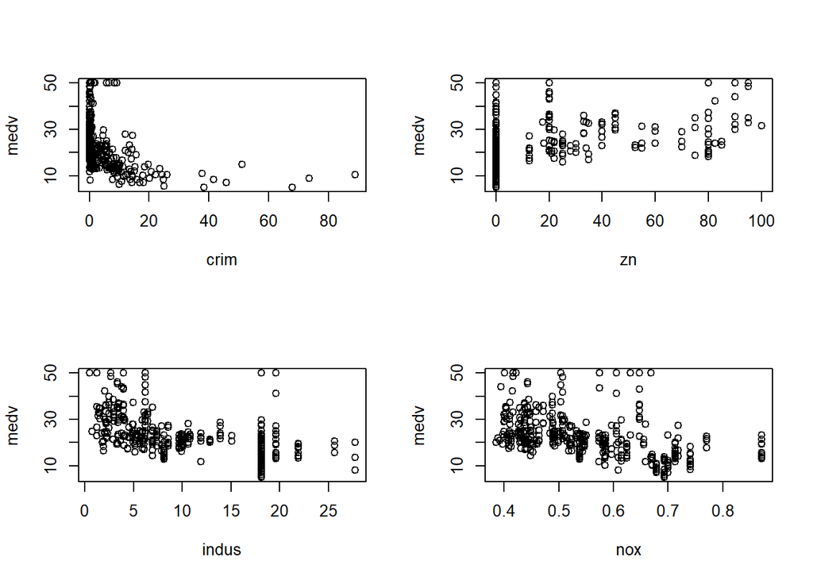

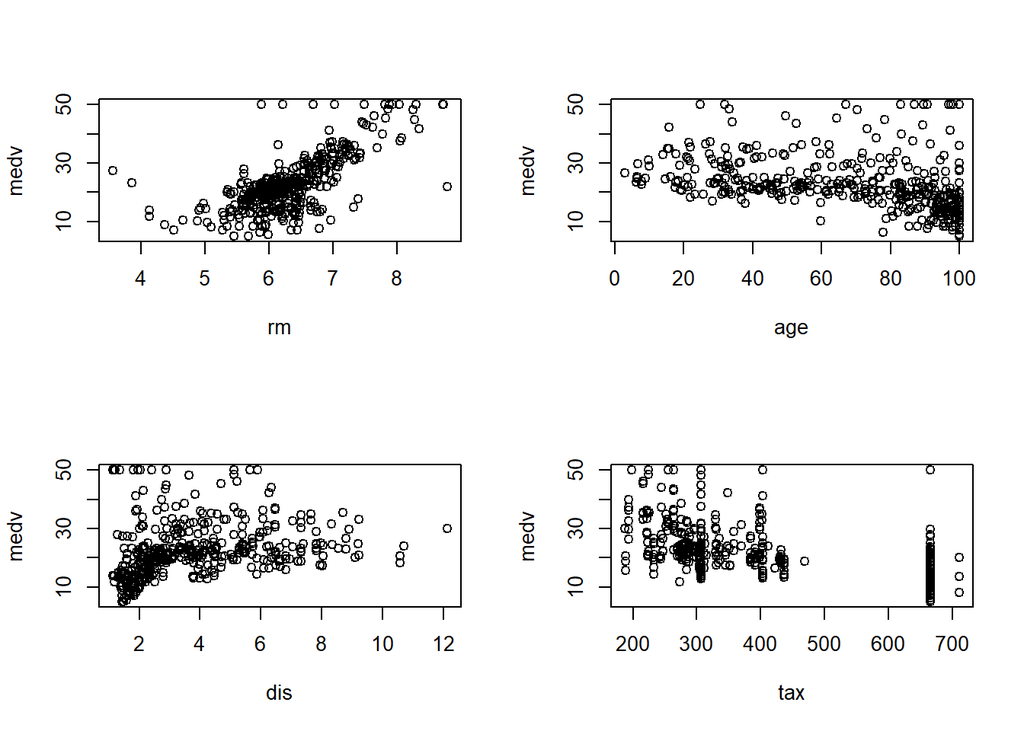

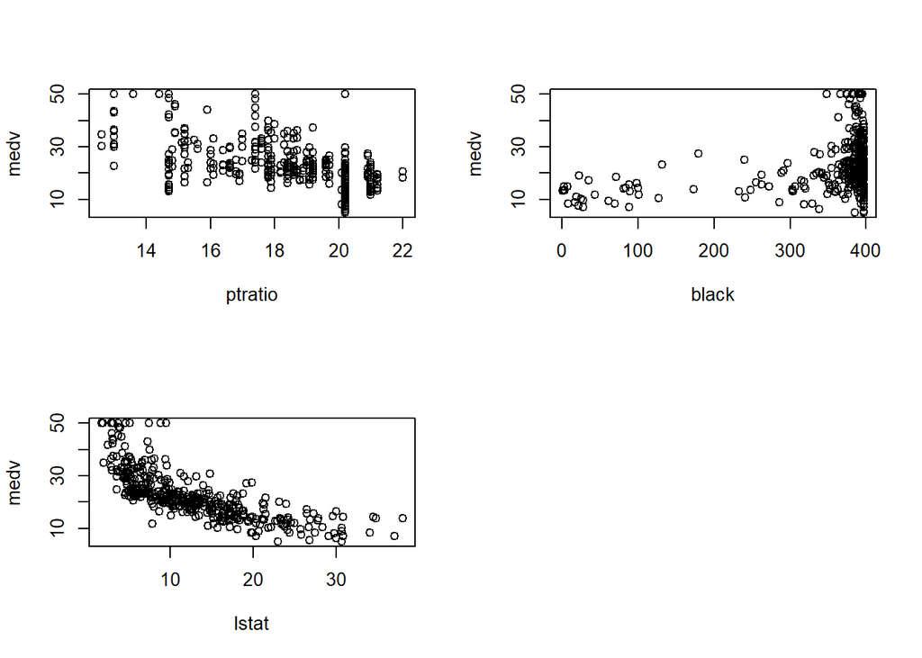

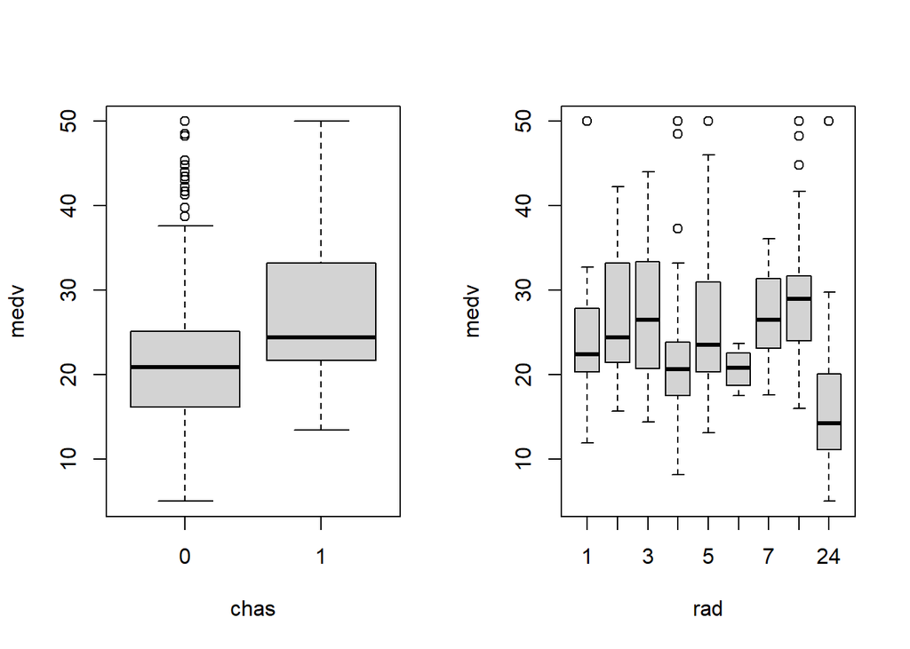

From the scatter plots it is possible to notice that the response variable may depend linearly on the predictors rm and lstat, while there is no evident linear relationship with the other independent variables. The boxplot of the variable chas highlights how the median price of a house in Boston tends to be higher if located close to a river. On the other hand, the median price increases up to a certain value of the variable rad and then decreases, as the closer a house is to the highway, the lower will be its price, but highway accessibility still has to be taken into consideration.

# Selection and description of different statistical models

## Linear models

Now, let us analyze several linear models. At first, we consider a linear model with all of the variables; then, we improve it by removing those variables whose t-test return a high p-value. A high p-value means that there is not sufficient evidence to refuse the null hypothesis, which for the t-test is $H_0: \beta_j = 0$. At last, we take into consideration a possible interaction effect.

```r
#Linear model 1: using all variables

lm1 = lm(data$medv ~., data = data[,1:13])
summary(lm1)
```

```
##
## Call:
## lm(formula = data$medv ~ ., data = data[, 1:13])
##
## Residuals:
##      Min       1Q   Median       3Q      Max
## -14.7281  -2.6738  -0.4367   1.8817  25.1553
##
## Coefficients:
##               Estimate Std. Error t value Pr(>|t|)
## (Intercept)  36.361604   5.962474   6.098 2.62e-09 ***
## crim         -0.110065   0.032438  -3.393 0.000763 ***
## zn            0.066545   0.014992   4.439 1.18e-05 ***
## indus         0.024717   0.076130   0.325 0.745606
## chas1         3.307360   0.912161   3.626 0.000327 ***
## nox         -18.117928   4.364063  -4.152 4.07e-05 ***
## rm            3.327557   0.466490   7.133 4.93e-12 ***
## age           0.012730   0.014853   0.857 0.391939
## dis          -1.494845   0.218151  -6.852 2.91e-11 ***
## rad2          1.046799   1.633144   0.641 0.521925
## rad3          4.657496   1.332929   3.494 0.000531 ***
## rad4          2.433528   1.190305   2.044 0.041592 *
## rad5          3.261919   1.218623   2.677 0.007754 **
## rad6          1.313957   1.537668   0.855 0.393355
## rad7          3.955066   1.680982   2.353 0.019136 *
## rad8          4.974255   1.505697   3.304 0.001044 **
## rad24         7.445991   1.932969   3.852 0.000137 ***
## tax          -0.009113   0.004548  -2.004 0.045819 *
## ptratio      -0.950795   0.160679  -5.917 7.27e-09 ***
## black         0.008991   0.002875   3.127 0.001898 **
## lstat        -0.544394   0.055934  -9.733  < 2e-16 ***
## ---
## Signif. codes:  0 '***' 0.001 '**' 0.01 '*' 0.05 '.' 0.1 ' ' 1
##
## Residual standard error: 4.527 on 383 degrees of freedom
## Multiple R-squared:  0.7711, Adjusted R-squared:  0.7591
## F-statistic:  64.5 on 20 and 383 DF,  p-value: < 2.2e-16
```

From the summary of the first linear model it is possible to infer that the coefficients of the variables age and indus are probably equal to zero, as their t-test returns a very high p-value, if compared to the significance level $1-\alpha = 0.95$. The $R^2$ of the model is $0.7711$. We also compute the AIC and plot the residuals.

```r
#AIC linear model 1

AIC(lm1)
```

```
## [1] 2389.136
```

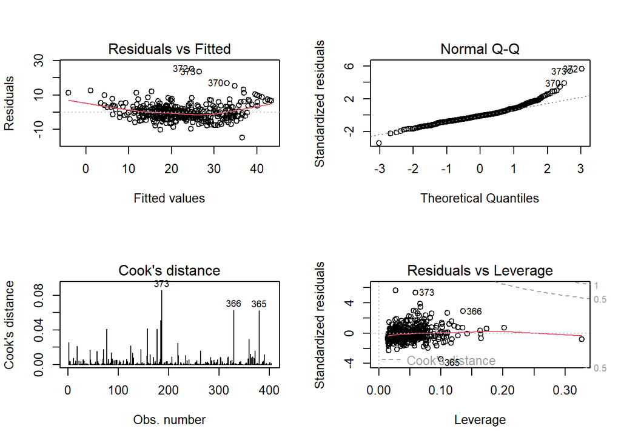

```r
#Residual plots:

par(mfrow = c(2,2))
plot(lm1, c(1,2,4,5))
```

The first plot suggests that the data are heteroscedastic and that there is no linearity. The second one rejects the normality assumption on the distribution. The third and fourth plots take into account the Cook’s distances: there are no observations which are extremely influential to the model.

We now fit a second linear model excluding the variables age and indus:

```r
#Linear model 2: using all variables except indus and age

lm2 = lm(data$medv ~ crim + zn + chas + nox + rm + dis + rad + tax + ptratio +
         black + lstat, data = data[,1:13])
summary(lm2)
```

```
##
## Call:
## lm(formula = data$medv ~ crim + zn + chas + nox + rm + dis +
##     rad + tax + ptratio + black + lstat, data = data[, 1:13])
##
## Residuals:
##      Min       1Q   Median       3Q      Max
## -14.9256  -2.6058  -0.4292   1.8288  25.4441
##
## Coefficients:
##               Estimate Std. Error t value Pr(>|t|)
## (Intercept)  35.612098   5.896115   6.040 3.64e-09 ***
## crim         -0.110551   0.032353  -3.417 0.000701 ***
## zn            0.063960   0.014559   4.393 1.45e-05 ***
## chas1         3.377825   0.902558   3.743 0.000210 ***
## nox         -16.714535   4.012222  -4.166 3.83e-05 ***
## rm            3.406714   0.451283   7.549 3.21e-13 ***
## dis          -1.556541   0.206500  -7.538 3.46e-13 ***
## rad2          1.172324   1.622214   0.723 0.470322
## rad3          4.598031   1.329051   3.460 0.000601 ***
## rad4          2.449699   1.184108   2.069 0.039231 *
## rad5          3.251025   1.215849   2.674 0.007817 **
## rad6          1.216344   1.524346   0.798 0.425395
## rad7          3.944976   1.677965   2.351 0.019224 *
## rad8          5.010980   1.493585   3.355 0.000873 ***
## rad24         7.215488   1.895447   3.807 0.000164 ***
## tax          -0.008360   0.004067  -2.056 0.040492 *
## ptratio      -0.931461   0.158987  -5.859 1.00e-08 ***
## black         0.009077   0.002866   3.168 0.001659 **
## lstat        -0.524759   0.051304 -10.228  < 2e-16 ***
## ---
## Signif. codes:  0 '***' 0.001 '**' 0.01 '*' 0.05 '.' 0.1 ' ' 1
##
## Residual standard error: 4.52 on 385 degrees of freedom
## Multiple R-squared:  0.7706, Adjusted R-squared:  0.7598
## F-statistic: 71.84 on 18 and 385 DF,  p-value: < 2.2e-16
```

The t-test on all the coefficients returns extremely low p-values, which means that every variable is statistically significant, with the exception of some coefficients of the categorical variable rad. However, not considering rad, or grouping some of its classes, led to worse models, so we decided to keep it.

Since the new model is nested in the previous one, we compare them by means of `anova`, analysis of variance, based on the F-test with null hypothesis $H_0: \beta_{age}, \beta_{indus} = 0$.

```r
#Anova

anova(lm1, lm2)
```

```
## Analysis of Variance Table
##
## Model 1: data$medv ~ crim + zn + indus + chas + nox + rm + age + dis +
##     rad + tax + ptratio + black + lstat
## Model 2: data$medv ~ crim + zn + chas + nox + rm + dis + rad + tax + ptratio +
##     black + lstat
##   Res.Df    RSS Df Sum of Sq     F Pr(>F)
## 1    383 7850.5
## 2    385 7867.4 -2   -16.971 0.414 0.6613
```

The high p-value suggests that there is not enough evidence to reject $H_0$. Hence, the simpler model is to be preferred. Moreover, the comparison of the AIC for the two models leads to the same conclusion: the simpler model achieves a lower AIC, thus is better.

```r
#AIC

AIC(lm1, lm2)
```

```
##     df      AIC
## lm1 22 2389.136
## lm2 20 2386.008
```

Let us analyze a new linear model looking for possible interactions between the variables. We expect that if the percentage of lower status population in the area is high, the median price will increase with respect to the number of rooms with lower steepness compared to when the percentage of the lower class is low.

We create a new categorical variable called class_lstat, equal to $0$ if the percentage is below the mean percentage, equal to $1$ if the percentage is higher than the mean percentage.

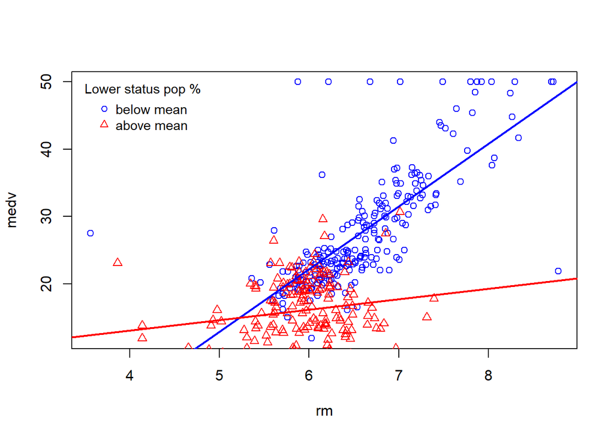

```r
#Creation of a new categorical variable

data$class_lstat = 1
data$class_lstat[which(data$lstat< mean(data$lstat))] = 0

linmod = lm(medv ~ rm, data = data[which(data$class_lstat == 0),])
linmod2 = lm(medv ~ rm, data = data[which(data$class_lstat == 1),])
plot(medv ~ rm, data = data[which(data$class_lstat == 0),], col = "blue", pch = 1)
points(medv ~ rm, data = data[which(data$class_lstat == 1),], col = "red", pch = 2)
abline(linmod, lwd = 2, col = "blue",)
abline(linmod2, lwd = 2, col = "red")
legend("topleft", title="Lower status pop %", inset=0.02, legend= c("below mean","above mean"),
       pch=c(1,2), col=c("blue","red"),cex=0.9,box.lty=0)
```

As expected, there is some possible interaction between rm and lstat. Hence, we fit a linear model with interaction.

```r
#Linear model 3: using interaction

lm3 = lm(data$medv ~ crim + zn + chas + nox + dis + rad + tax + black + ptratio + rm*lstat,
         data =data[,1:13])
summary(lm3)
```

```
##
## Call:
## lm(formula = data$medv ~ crim + zn + chas + nox + dis + rad +
##     tax + black + ptratio + rm * lstat, data = data[, 1:13])
##
## Residuals:
##      Min       1Q   Median       3Q      Max
## -21.0113  -2.3464  -0.1642   1.6655  25.7304
##
## Coefficients:
##               Estimate Std. Error t value Pr(>|t|)
## (Intercept)   7.258419   5.947206   1.220 0.223034
## crim         -0.147837   0.029019  -5.094 5.50e-07 ***
## zn            0.038012   0.013205   2.879 0.004217 **
## chas1         2.940114   0.804161   3.656 0.000292 ***
## nox         -13.106019   3.587402  -3.653 0.000295 ***
## dis          -1.236748   0.186419  -6.634 1.11e-10 ***
## rad2          1.153678   1.443268   0.799 0.424581
## rad3          4.342178   1.182713   3.671 0.000275 ***
## rad4          2.612105   1.053611   2.479 0.013596 *
## rad5          3.311602   1.081745   3.061 0.002358 **
## rad6          2.144097   1.359291   1.577 0.115535
## rad7          3.594142   1.493271   2.407 0.016560 *
## rad8          3.682707   1.335296   2.758 0.006094 **
## rad24         7.701560   1.687043   4.565 6.73e-06 ***
## tax          -0.008294   0.003618  -2.292 0.022430 *
## black         0.003955   0.002599   1.522 0.128889
## ptratio      -0.734681   0.142780  -5.146 4.26e-07 ***
## rm            7.399055   0.562915  13.144  < 2e-16 ***
## lstat         1.589719   0.213894   7.432 7.00e-13 ***
## rm:lstat     -0.368614   0.036429 -10.119  < 2e-16 ***
## ---
## Signif. codes:  0 '***' 0.001 '**' 0.01 '*' 0.05 '.' 0.1 ' ' 1
##
## Residual standard error: 4.022 on 384 degrees of freedom
## Multiple R-squared:  0.8189, Adjusted R-squared:  0.8099
## F-statistic: 91.37 on 19 and 384 DF,  p-value: < 2.2e-16
```

We compare the model with interaction with the previous ones, using the Akaike information criteria:

```r
#AIC

AIC(lm1, lm2, lm3)
```

```
##     df      AIC
## lm1 22 2389.136
## lm2 20 2386.008
## lm3 21 2292.516
```

This confirms that the model with interaction works better. Again, we analyze the residual plots:

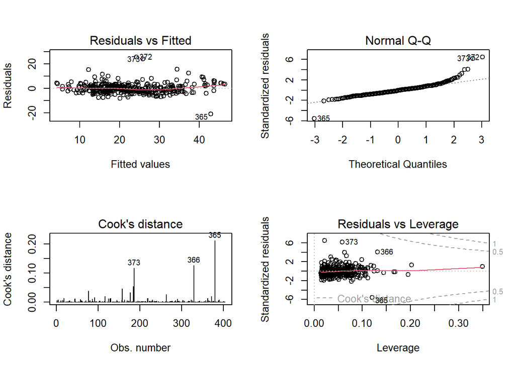

```r
#Residual plots

par(mfrow = c(2,2))
plot(lm3, c(1,2,4,5))
```

The first plot suggests that the data are heteroscedastic, but to a less degree if compared to the first linear model. Also the linearity assumption seems to be a bit more appropriate, even if not to a sufficient degree. The second plot rejects the normality assumption on the distribution, but it is still way better than the first model. The third and fourth plots take into account the Cook’s distances: there are no observations which are extremely influential to the model.

## Penalized linear models

Now, we fit two linear models with the lasso regularization technique, choosing as the first $\lambda$ value the one which minimizes the cross validation error, and as the second the one found by the 1-standard error rule. Recall that the lasso is a specific type of penalization with the following form:

$$\hat{\beta} =
argmin_{\beta}\left[\left(y-X\beta\right)^t\left(y-X\beta\right)\right]
+ \lambda\sum_{j=1}^{p} \lvert\beta_j\rvert$$
Below the plot of the coefficients’ values against increasing values of $\log\lambda$.

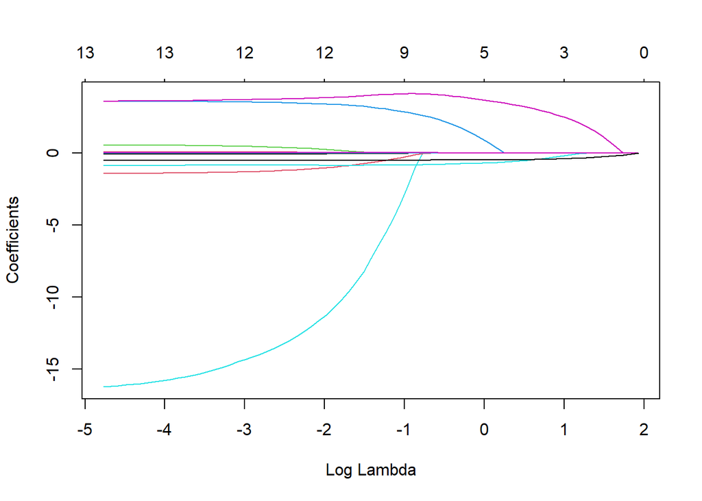

```r
library(glmnet)
library(caret)

#Create a matrix with all independent variables (if not, the code below will not work)

x = cbind(data$crim, data$zn, data$indus, data$chas, data$nox, data$rm, data$age,
          data$dis, data$rad, data$tax, data$ptratio, data$black, data$lstat)
lm_lasso <- glmnet(x, data$medv, alpha=1, family="gaussian")
plot(lm_lasso, "lambda")
```

This is the model fitted with the value of $\lambda$ which minimizes the cross validation error:

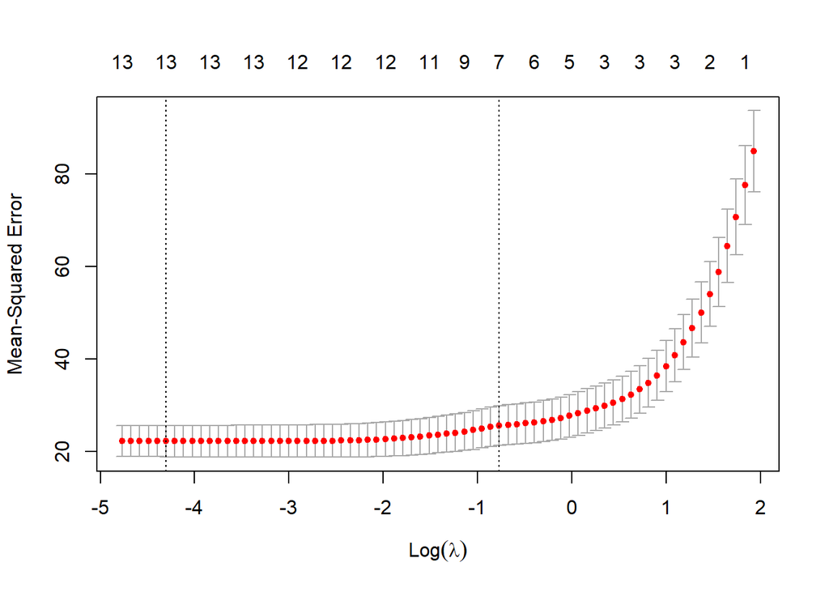

```r
#Set seed and find best lambda

set.seed(2001)
cv<-cv.glmnet(x,data$medv, alpha=1, family="gaussian",type.measure="mse")
plot(cv)
```

```r
#Best value for lambda found using 10-cross fold validation

lm_lasso_min = glmnet(x, data$medv, alpha=1,family="gaussian", lambda = cv$lambda.min)

sprintf("R2: %f", lm_lasso_min$dev.ratio)
```

```
## [1] "R2: 0.757691"
```

This is the model fitted with the value of $\lambda$ which follows the 1-standard error rule:

```r
lm_lasso_1se = glmnet(x, data$medv, alpha=1,family="gaussian", lambda = cv$lambda.1se)
sprintf("R2: %f", lm_lasso_1se$dev.ratio)
```

```
## [1] "R2: 0.713292"
```

## Generalized linear models

The analysis of the linear models has led to the conclusion that the assumption on normality does not hold to a sufficient degree. Recall that $y = \text{medv}$ is the median value of owner-occupied homes in thousand dollars, thus $y\in[0,\infty)$. Hence, we can assume that $y$ is distributed following a Gamma distribution and, eventually, use a generalized linear model. We now plot the histogram of the observed data against the theoretical gamma distribution and the estimated distribution via the kernel:

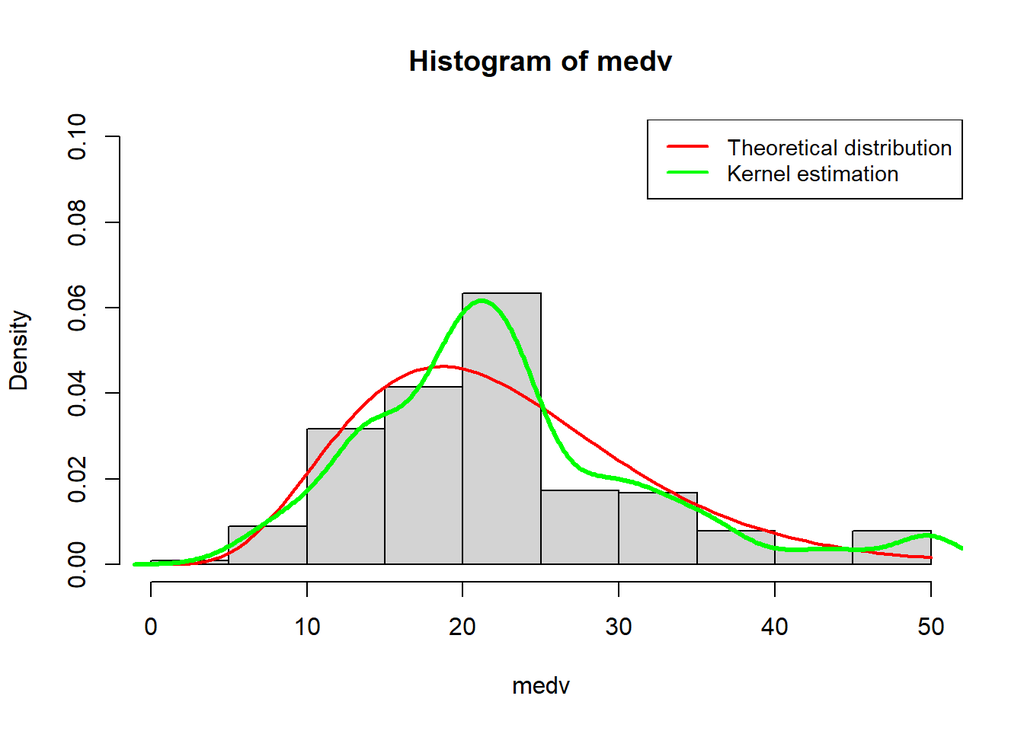

Recall that the pdf $f_Y$ of a random variable $Y$ distributed as a $Gamma(\alpha,\lambda)$ is defined as:

$$f_Y(y)= \frac{1}{\Gamma(\alpha)}y^{\alpha-1}\lambda^{\alpha}e^{-\lambda
y}\qquad y\in[0,\infty)$$

Moreover, its expected value is given by $\mu = \mathbb{E}[Y] = \frac{\alpha}{\lambda}$.Then, it is possible to observe that the Gamma distribution belongs to the exponential family:

$$f_Y(y) = e^{-\lambda y + \alpha\log(\lambda) + (\alpha-1)y
-\log(\Gamma(\alpha))} = e^{\frac{\lambda y - \alpha\log(\lambda)}{-1} +
c\left(-1,\ y\right)}$$

Thus, $\lambda = \theta$ and $b(\lambda)= \alpha\log(\lambda)$. Since for the exponential family the canonical link function is defined as $g = \left(b'\right)^{-1}$, we obtain $g(\lambda) = \frac{\lambda}{\alpha} = \frac{1}{\mu}$. Hence, the canonical link function for the Gamma distribution is the inverse function $g(x) = \frac{1}{x}$.

Now, let us analyze several generalized linear models. At first, we consider a glm with all of the variables; then, we fit a glm selecting the variables with respect to the t-tests on the coefficients.

```r
#Generalized linear model 1: using all the variables

glm1 = glm(data$medv ~ ., data = data[,1:13], family = "Gamma")
summary(glm1)
```

```
##
## Call:
## glm(formula = data$medv ~ ., family = "Gamma", data = data[,
##     1:13])
##
## Deviance Residuals:
##      Min        1Q    Median        3Q       Max
## -0.64001  -0.09927  -0.02146   0.07918   0.89501
##
## Coefficients:
##               Estimate Std. Error t value Pr(>|t|)
## (Intercept)  7.784e-03  1.106e-02   0.704 0.482005
## crim         9.557e-04  1.376e-04   6.946 1.62e-11 ***
## zn          -4.332e-05  2.256e-05  -1.920 0.055595 .
## indus       -7.406e-05  1.315e-04  -0.563 0.573755
## chas1       -3.744e-03  1.287e-03  -2.909 0.003839 **
## nox          2.947e-02  8.709e-03   3.384 0.000788 ***
## rm          -2.307e-03  7.952e-04  -2.901 0.003932 **
## age         -5.049e-05  2.611e-05  -1.933 0.053946 .
## dis          1.659e-03  3.764e-04   4.408 1.36e-05 ***
## rad2        -3.125e-03  2.535e-03  -1.233 0.218387
## rad3        -6.732e-03  2.099e-03  -3.207 0.001456 **
## rad4        -2.821e-03  1.960e-03  -1.439 0.150876
## rad5        -5.156e-03  1.974e-03  -2.613 0.009342 **
## rad6        -3.670e-03  2.765e-03  -1.327 0.185304
## rad7        -6.497e-03  2.648e-03  -2.454 0.014589 *
## rad8        -6.711e-03  2.346e-03  -2.861 0.004450 **
## rad24       -1.814e-02  3.663e-03  -4.952 1.10e-06 ***
## tax          1.606e-05  8.221e-06   1.954 0.051449 .
## ptratio      1.390e-03  2.796e-04   4.972 1.00e-06 ***
## black       -2.573e-05  8.299e-06  -3.101 0.002073 **
## lstat        1.675e-03  1.217e-04  13.764  < 2e-16 ***
## ---
## Signif. codes:  0 '***' 0.001 '**' 0.01 '*' 0.05 '.' 0.1 ' ' 1
##
## (Dispersion parameter for Gamma family taken to be 0.03531824)
##
##     Null deviance: 66.674  on 403  degrees of freedom
## Residual deviance: 12.799  on 383  degrees of freedom
## AIC: 2250.9
##
## Number of Fisher Scoring iterations: 5
```

Once again, from the summary of the first generalized linear model it is possible to infer that the coefficients of the indus variable is probably equal to zero, as its t-test returns an extremely high p-value. The AIC of the model is:

```r
#AIC

AIC(glm1)
```

```
## [1] 2250.905
```

The reported value is lower than the one of the best linear model, hence it is to be preferred. We can further improve the glm by excluding the indus variable.

```r
#Generalized linear model 2: selecting variables and interaction

glm2 = glm(data$medv ~ zn + age + tax + crim + chas + nox + dis + rad + ptratio + rm + black + lstat,
           data = data[,1:13], family = "Gamma")
summary(glm2)
```

```
##
## Call:
## glm(formula = data$medv ~ zn + age + tax + crim + chas + nox +
##     dis + rad + ptratio + rm + black + lstat, family = "Gamma",
##     data = data[, 1:13])
##
## Deviance Residuals:
##      Min        1Q    Median        3Q       Max
## -0.63997  -0.10185  -0.02261   0.07615   0.89585
##
## Coefficients:
##               Estimate Std. Error t value Pr(>|t|)
## (Intercept)  8.059e-03  1.103e-02   0.731 0.465427
## zn          -4.050e-05  2.201e-05  -1.840 0.066500 .
## age         -5.118e-05  2.607e-05  -1.964 0.050309 .
## tax          1.383e-05  7.200e-06   1.921 0.055451 .
## crim         9.546e-04  1.373e-04   6.950 1.57e-11 ***
## chas1       -3.921e-03  1.247e-03  -3.144 0.001795 **
## nox          2.846e-02  8.514e-03   3.343 0.000909 ***
## dis          1.682e-03  3.736e-04   4.504 8.88e-06 ***
## rad2        -3.065e-03  2.528e-03  -1.212 0.226126
## rad3        -6.706e-03  2.097e-03  -3.198 0.001500 **
## rad4        -2.942e-03  1.946e-03  -1.511 0.131557
## rad5        -5.111e-03  1.969e-03  -2.596 0.009799 **
## rad6        -3.545e-03  2.754e-03  -1.287 0.198806
## rad7        -6.437e-03  2.642e-03  -2.436 0.015295 *
## rad8        -6.560e-03  2.326e-03  -2.820 0.005053 **
## rad24       -1.776e-02  3.600e-03  -4.933 1.21e-06 ***
## ptratio      1.380e-03  2.788e-04   4.951 1.11e-06 ***
## rm          -2.262e-03  7.887e-04  -2.867 0.004365 **
## black       -2.543e-05  8.267e-06  -3.077 0.002243 **
## lstat        1.677e-03  1.215e-04  13.797  < 2e-16 ***
## ---
## Signif. codes:  0 '***' 0.001 '**' 0.01 '*' 0.05 '.' 0.1 ' ' 1
##
## (Dispersion parameter for Gamma family taken to be 0.0352199)
##
##     Null deviance: 66.674  on 403  degrees of freedom
## Residual deviance: 12.810  on 384  degrees of freedom
## AIC: 2249.3
##
## Number of Fisher Scoring iterations: 5
```

The two models are nested, hence we can compare them by means of anova:

```r
#Anova

anova(glm1, glm2, test = "LRT")
```

```
## Analysis of Deviance Table
##
## Model 1: data$medv ~ crim + zn + indus + chas + nox + rm + age + dis +
##     rad + tax + ptratio + black + lstat
## Model 2: data$medv ~ zn + age + tax + crim + chas + nox + dis + rad +
##     ptratio + rm + black + lstat
##   Resid. Df Resid. Dev Df  Deviance Pr(>Chi)
## 1       383     12.799
## 2       384     12.810 -1 -0.011144   0.5743
```

The high p-value suggests that there is not enough evidence to reject $H_0$. Hence, the simpler model is to be preferred. Moreover, the comparison of the AIC for the two models leads to the same conclusion: the simpler model achieves a lower AIC, thus is better.

```r
#AIC

AIC(glm1, glm2)
```

```
##      df      AIC
## glm1 22 2250.905
## glm2 21 2249.258
```

Let us discuss the plots of the residuals of the second generalized linear model:

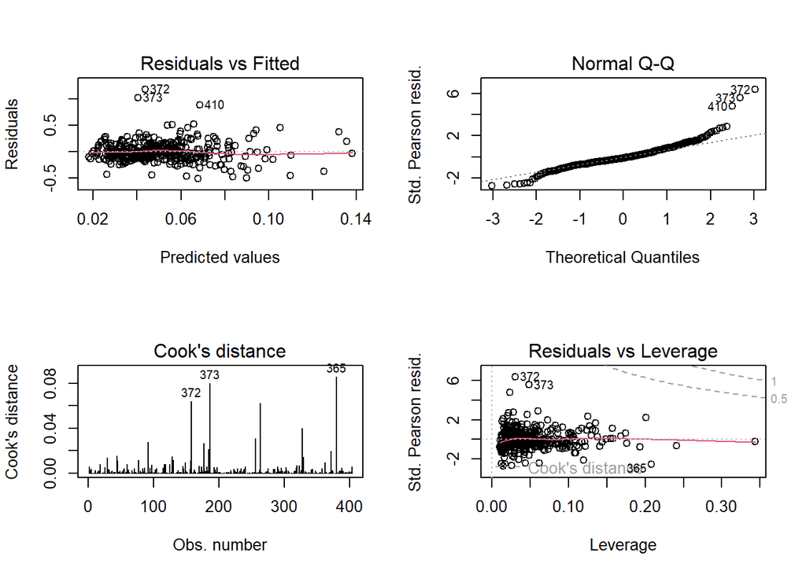

```r
#Residual plots

par(mfrow = c(2,2))
plot(glm2, c(1,2,4,5))
```

The first residual plot suggests that the transformed variables are now homoscedastic and follow a more linear trend, hence the glm performs better than the linear model in this sense. However, the second plot still highlights some issues with the normality assumption on the transformed variables. thus one could think that a general additive model could be better. The last two plots regarding the Cook’s distances still confirm that there are no observations which are particularly influential.

## General additive models

At the beginning of the presentation, we plotted the graphs of the response variable against each predictor in order to spot some linear dependence. Now, we would like to generalize this concept in order to find a non-linear dependence. To achieve this goal, we introduce non-linear terms in the linear predictor using smoothing splines. Hence, we fit several generalized additive models by removing some variables depending on the results of the t-tests performed on the coefficients. At last, we choose the generalized linear model which has lower AIC.

```r
library(mgcv)

#Select = TRUE allows to add extra penalty to each term so that it can be

gam1 <- gam(medv ~ s(zn) + s(crim) + s(indus) + s(nox) + s(rm) + s(age) + s(dis) + s(tax) + s(ptratio)
            + s(black) + s(lstat) + rad + chas, data = data, family = Gamma, method = "GCV.Cp",
            select = "TRUE")
summary(gam1)
```

```
##
## Family: Gamma
## Link function: inverse
##
## Formula:
## medv ~ s(zn) + s(crim) + s(indus) + s(nox) + s(rm) + s(age) +
##     s(dis) + s(tax) + s(ptratio) + s(black) + s(lstat) + rad +
##     chas
##
## Parametric coefficients:
##              Estimate Std. Error t value Pr(>|t|)
## (Intercept)  0.059945   0.002949  20.328  < 2e-16 ***
## rad2        -0.001375   0.002140  -0.642  0.52104
## rad3        -0.004798   0.001863  -2.576  0.01041 *
## rad4        -0.002407   0.001676  -1.436  0.15183
## rad5        -0.003253   0.001792  -1.815  0.07039 .
## rad6        -0.002590   0.002230  -1.162  0.24615
## rad7        -0.004165   0.002450  -1.700  0.08999 .
## rad8        -0.004430   0.002296  -1.929  0.05449 .
## rad24       -0.023392   0.008969  -2.608  0.00949 **
## chas1       -0.001722   0.001077  -1.599  0.11065
## ---
## Signif. codes:  0 '***' 0.001 '**' 0.01 '*' 0.05 '.' 0.1 ' ' 1
##
## Approximate significance of smooth terms:
##                  edf Ref.df      F  p-value
## s(zn)      2.366e-01      9  0.058 0.124548
## s(crim)    4.650e+00      9  9.316  < 2e-16 ***
## s(indus)   2.403e-06      9  0.000 0.907212
## s(nox)     7.834e+00      9 10.678  < 2e-16 ***
## s(rm)      3.988e+00      9  9.331  < 2e-16 ***
## s(age)     8.448e-01      9  0.422 0.031565 *
## s(dis)     8.787e+00      9  7.090  < 2e-16 ***
## s(tax)     5.699e+00      9  2.513 0.000411 ***
## s(ptratio) 9.290e-01      9  2.872  < 2e-16 ***
## s(black)   5.747e+00      9  2.337 0.000796 ***
## s(lstat)   4.374e+00      9 17.139  < 2e-16 ***
## ---
## Signif. codes:  0 '***' 0.001 '**' 0.01 '*' 0.05 '.' 0.1 ' ' 1
##
## R-sq.(adj) =   0.88   Deviance explained = 89.2%
## GCV = 0.023537  Scale est. = 0.020468  n = 404
```

For the first generalized additive model we consider the categorical variables as linear predictors, since we cannot apply splines to them. However, the t-test on the coefficients returns a high p-value, hence we do not consider chas and rad for the second gam.

```r
gam2 <- gam(medv ~ s(zn) + s(crim) + s(indus) + s(nox) + s(rm) + s(age) + s(dis) + s(tax) + s(ptratio)
            + s(black) + s(lstat), data = data, family = Gamma, method = "GCV.Cp", select = "TRUE")
summary(gam2)
```

```
##
## Family: Gamma
## Link function: inverse
##
## Formula:
## medv ~ s(zn) + s(crim) + s(indus) + s(nox) + s(rm) + s(age) +
##     s(dis) + s(tax) + s(ptratio) + s(black) + s(lstat)
##
## Parametric coefficients:
##              Estimate Std. Error t value Pr(>|t|)
## (Intercept) 0.0511738  0.0003911   130.9   <2e-16 ***
## ---
## Signif. codes:  0 '***' 0.001 '**' 0.01 '*' 0.05 '.' 0.1 ' ' 1
##
## Approximate significance of smooth terms:
##                  edf Ref.df      F  p-value
## s(zn)      1.092e-05      9  0.000 0.439171
## s(crim)    4.051e+00      9  9.180  < 2e-16 ***
## s(indus)   8.256e-06      9  0.000 0.645794
## s(nox)     7.895e+00      9 11.265  < 2e-16 ***
## s(rm)      4.080e+00      9 10.055  < 2e-16 ***
## s(age)     8.851e-01      9  0.466 0.027358 *
## s(dis)     8.769e+00      9  8.425  < 2e-16 ***
## s(tax)     7.075e+00      9  4.471 6.69e-07 ***
## s(ptratio) 1.871e+00      9  4.262  < 2e-16 ***
## s(black)   5.746e+00      9  2.346 0.000764 ***
## s(lstat)   4.600e+00      9 17.538  < 2e-16 ***
## ---
## Signif. codes:  0 '***' 0.001 '**' 0.01 '*' 0.05 '.' 0.1 ' ' 1
##
## R-sq.(adj) =  0.879   Deviance explained =   89%
## GCV = 0.023166  Scale est. = 0.020531  n = 404
```

Similar considerations can be drawn for the second generalized additive model: the t-test for the coefficient of the variable indus returns a very high p-value, hence it can be excluded from the following model.

```r
gam3 <- gam(medv ~ s(crim) + s(age)  + s(nox) + s(rm) + s(dis) + s(tax) + s(ptratio) + s(black) + s(lstat),
            data = data, family = Gamma, method = "GCV.Cp", select = "TRUE")
summary(gam3)
```

```
##
## Family: Gamma
## Link function: inverse
##
## Formula:
## medv ~ s(crim) + s(age) + s(nox) + s(rm) + s(dis) + s(tax) +
##     s(ptratio) + s(black) + s(lstat)
##
## Parametric coefficients:
##             Estimate Std. Error t value Pr(>|t|)
## (Intercept) 0.051175   0.000391   130.9   <2e-16 ***
## ---
## Signif. codes:  0 '***' 0.001 '**' 0.01 '*' 0.05 '.' 0.1 ' ' 1
##
## Approximate significance of smooth terms:
##               edf Ref.df      F  p-value
## s(crim)    4.2140      9  9.139  < 2e-16 ***
## s(age)     0.8831      9  0.469 0.026619 *
## s(nox)     7.8938      9 11.186  < 2e-16 ***
## s(rm)      4.0819      9 10.055  < 2e-16 ***
## s(dis)     8.7703      9  8.280  < 2e-16 ***
## s(tax)     7.0575      9  4.358 9.56e-07 ***
## s(ptratio) 1.8369      9  4.297  < 2e-16 ***
## s(black)   5.7461      9  2.316 0.000884 ***
## s(lstat)   4.6406      9 17.529  < 2e-16 ***
## ---
## Signif. codes:  0 '***' 0.001 '**' 0.01 '*' 0.05 '.' 0.1 ' ' 1
##
## R-sq.(adj) =  0.879   Deviance explained =   89%
## GCV = 0.023215  Scale est. = 0.020522  n = 404
```

```r
AIC(gam1, gam2, gam3)
```

```
##            df      AIC
## gam1 54.08984 2084.344
## gam2 46.97198 2078.865
## gam3 47.12414 2079.605
```

At last, we analyze the plots of the residuals:

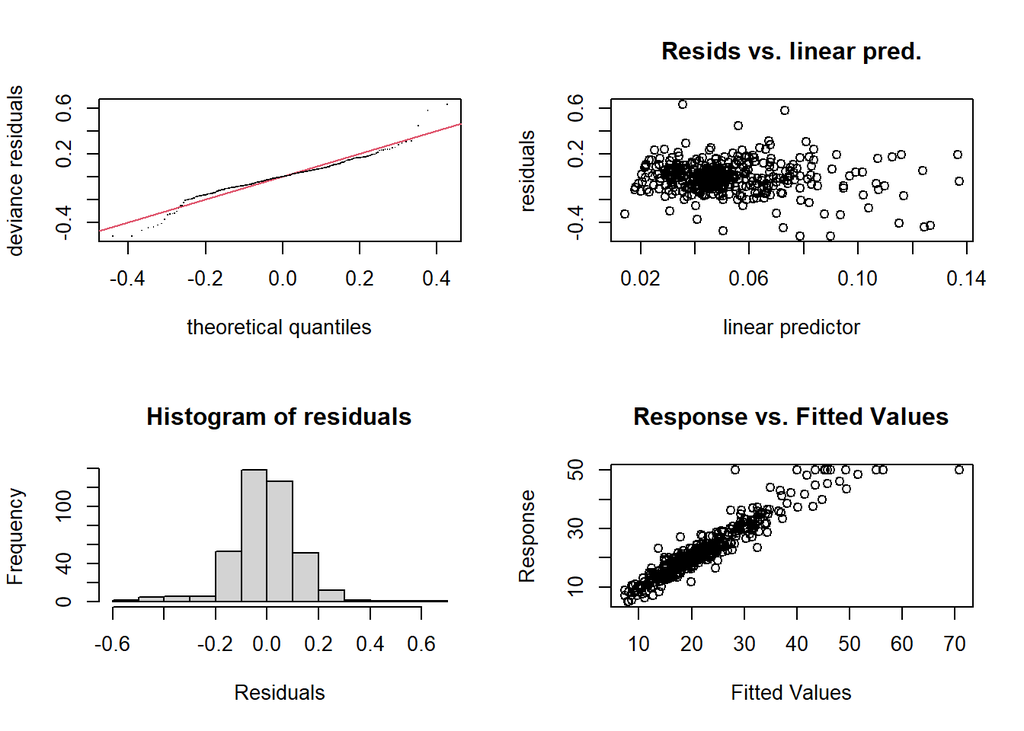

```
##
## Method: GCV   Optimizer: outer newton
## full convergence after 19 iterations.
## Gradient range [-1.655344e-09,3.291305e-08]
## (score 0.0232155 & scale 0.02052185).
## eigenvalue range [-1.100743e-09,0.0001742734].
## Model rank =  82 / 82
##
## Basis dimension (k) checking results. Low p-value (k-index<1) may
## indicate that k is too low, especially if edf is close to k'.
##
##               k'   edf k-index p-value
## s(crim)    9.000 4.214    1.00   0.480
## s(age)     9.000 0.883    0.98   0.275
## s(nox)     9.000 7.894    0.92   0.045 *
## s(rm)      9.000 4.082    0.97   0.245
## s(dis)     9.000 8.770    0.85  <2e-16 ***
## s(tax)     9.000 7.057    0.95   0.190
## s(ptratio) 9.000 1.837    1.00   0.490
## s(black)   9.000 5.746    1.05   0.845
## s(lstat)   9.000 4.641    1.08   0.955
## ---
## Signif. codes:  0 '***' 0.001 '**' 0.01 '*' 0.05 '.' 0.1 ' ' 1
```

```r
#Residuals plots

par(mfrow = c(2,2))
gam.check(gam3)
```

The results are optimal, since all the assumptions on the transformed variables seem to hold: linearity, normality and homoscedasticity.

# Comparison between the different models

```r
AIC(lm3, glm2, gam3)
```

```
##            df      AIC
## lm3  21.00000 2292.516
## glm2 21.00000 2249.258
## gam3 47.12414 2079.605
```

The analysis of the AIC suggests that the generalized additive model performs better on the data.

Now, we would like to see how the three selected models plus the linear model with lasso regression behave on unseen data (test set). We compare them by means of the following performance indexes: root mean squared error (RMSE), mean absolute error (MAE), and mean absolute percentage error (MAPE).

```
## [1] "Linear model - RMSE: 4.455031, MAE: 2.964928, MAPE: 0.136945"
```

```
## [1] "Linear model with lasso - RMSE: 5.433221, MAE: 3.527172, MAPE: 0.156852"
```

```
## [1] "Generalized linear model - RMSE: 4.342674, MAE: 2.978782, MAPE: 0.136782"
```

```
## [1] "Generalized additive model - RMSE: 3.297192, MAE: 2.496497, MAPE: 0.127045"
```

The results on the test set seem to be coherent with what we already established by looking at the AIC of the different models: the general additive model is to be considered the best choice to describe the behaviour of the factors affecting the domestic property median value in the city of Boston.